# Ensambles - Clase 2

# Introducción

Primero, leemos la base:

```r
library(tidyverse)

data <- read_delim("./data/enut2021_base.txt", delim = "|")

data <- data %>% select(ID, SEXO_SEL, EDAD_SEL, TCS_GRUPO_DOMESTICO, CONDICION_ACTIVIDAD_AGRUPADA,
                        NIVEL_EDUCATIVO_AGRUPADO, CANT_DEMANDANTES_TOTAL, CANT_NODEMANDANTES_TOTAL,
                        BHCH04_SEL, BHDC_SEL) %>%
  mutate(realiza_domest = as.factor(case_when(
    TCS_GRUPO_DOMESTICO > 60 ~ "Realiza",
    TRUE ~ "No realiza")))

data <- data %>% mutate_at(
                   vars(SEXO_SEL),
                    ~as.factor(case_when(
                      . == 1 ~ "Mujer",
                      . == 2 ~ "Varón"
                    )))



data <- data %>% mutate_at(vars(CONDICION_ACTIVIDAD_AGRUPADA),
                   ~as.factor(case_when(
                     . == 1 ~ "Ocupado",
                     . == 2 ~ "No ocupado"
                   )))

data <- data %>% mutate_at(vars(BHCH04_SEL),
                   ~as.factor(case_when(
                     . == 1 ~ "Jefe/a",
                     . == 2 ~ "Cónyuge/pareja",
                     . == 3 ~ "Hijo/a",
                     . == 4 ~ "Hijastro/a",
                     . == 5 ~ "Yerno/nuera",
                     . == 6 ~ "Nieto/a",
                     . == 7 ~ "Padre o madre",
                     . == 8 ~ "Suegro/a",
                     . == 9 ~ "Hermano/a",
                     . == 10 ~ "Cuñado/a",
                     . == 11 ~ "Sobrino/a",
                     . == 12 ~ "Abuelo/a",
                     . == 13 ~ "Otro familiar",
                     . == 14 ~ "Otro no familiar")))



 data <- data %>% mutate_at(vars(BHDC_SEL),
                   ~as.factor(case_when(
                     . == 0 ~ "No es demandante de cuidado",
                     . == 1 ~ "Es demandante de cuidado"
                   )))

data<- data %>% select(-TCS_GRUPO_DOMESTICO)
```

# Pruebas anteriores

Primero, retomemos los resultados que obtuvimos haciendo modelos con un árbol simple y con bagging.

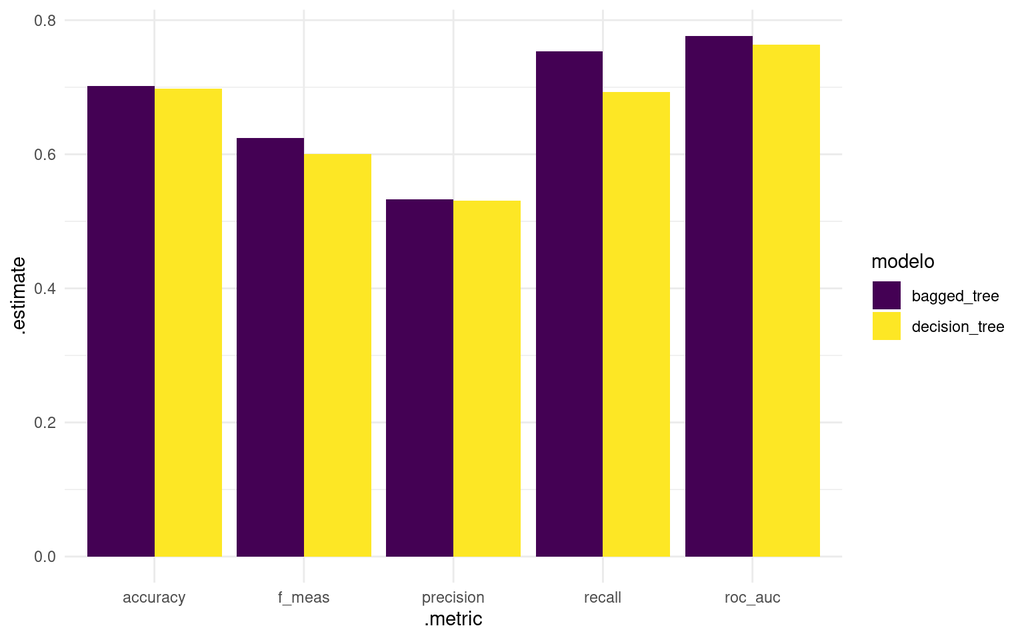

```r
decision_tree <- readRDS('./data/validation_test_dt.RDS')
bagging <- readRDS('./data/validation_test_bag.RDS')

class_metrics <- metric_set(precision, recall,
                       accuracy, f_meas)

metrics_dt <- roc_auc(decision_tree, truth = realiza_domest, estimate = ".pred_No realiza") %>%
  bind_rows(., class_metrics(decision_tree, truth = realiza_domest, estimate = .pred_class))%>%
  mutate(modelo = "decision_tree")

metrics_bagging <- roc_auc(bagging, truth = realiza_domest, estimate = ".pred_No realiza") %>%
  bind_rows(., class_metrics(bagging, truth = realiza_domest, estimate = .pred_class))%>%
  mutate(modelo = "bagged_tree")

rbind(metrics_dt, metrics_bagging) %>%
  ggplot(aes(x = .metric, y = .estimate, fill = modelo))+
  geom_col(position = "dodge")+
  scale_fill_viridis_d()+
  theme_minimal()
```

# Modelado

## Inicio del workflow

La primera parte va a ser igual a lo que veníamos haciendo. Train y test, receta e instanciar el workflow.

```r
set.seed(123)

split <- initial_split(data)
train <- training(split)
test <- testing(split)

recipe <- recipe(realiza_domest ~ ., data = train)%>%
  update_role(ID, new_role = "id") %>%
  step_other(BHCH04_SEL, threshold = 0.2)%>%
  step_downsample(realiza_domest, under_ratio = 1)

wf <- workflow() %>%
  add_recipe(recipe)

wf
```

```
## ══ Workflow ════════════════════════════════════════════════════════════════════
## Preprocessor: Recipe
## Model: None
##
## ── Preprocessor ────────────────────────────────────────────────────────────────
## 2 Recipe Steps
##
## • step_other()
## • step_downsample()
```

## Hiperparámetros

Ahora, hay que generar el modelo de random forest. Esto lo hacemos con la función `rand_forest()`. Los hiperparámetros con los que vamos a jugar acá son:

- `trees`: define el número de árboles que se van a probar,
- `mtry`: la cantidad de variables que se van a probar en cada iteración
- `min_n`: mínima cantidad de observaciones que tiene que haber en cada nodo

```r
rf_spec <- rand_forest(
  trees = 1000,
  mtry = tune(),
  min_n = tune()
  ) %>%
  set_mode("classification") %>%
  set_engine("ranger")
```

Hasta ahora, veníamos tuneando los hiperparámetros en base a combinaciones de grids random. Sin embargo, para este tipo de modelo tenemos un hiperparámetro que no puede adoptar valores random: `mtry`. Este valor depende de la cantidad de variables que tengamos en el modelo. Por lo tanto, vamos a usar la función tune_grid() directamente sobre el modelo y le vamos a pasar grid = 30 en lugar de un dataframe con posibles combinaciones, para indicarle que pruebe 30 parámetros distintos basados en el dataframe.

```r
tune_wf <- wf %>%
  add_model(rf_spec)

set.seed(1912)

folds <- vfold_cv(train)

tune_params <- tune_grid(tune_wf,
                         resamples = folds,
                         grid = 30,
                         metrics = metric_set(precision, recall,
                                              roc_auc, f_meas))
```

Grafiquemos los resultados.

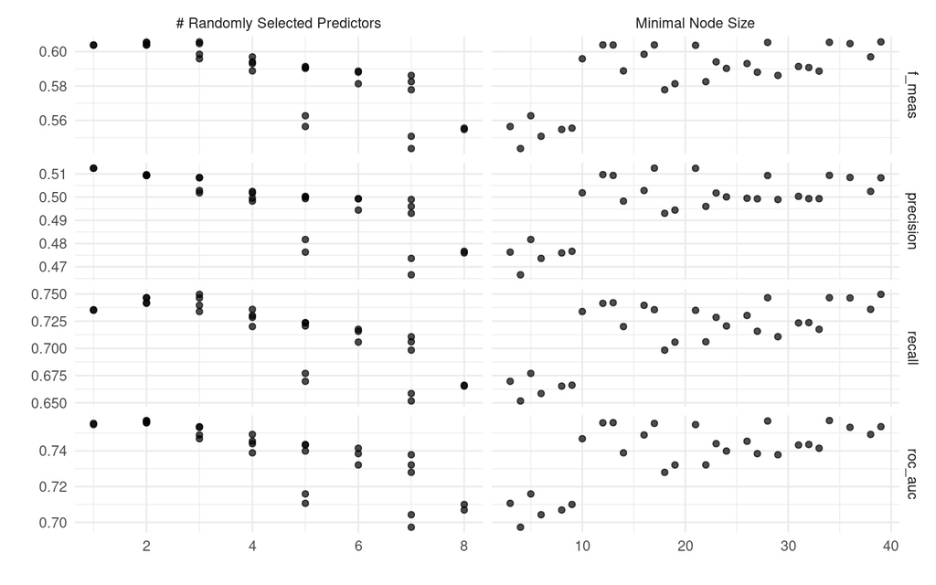

```r
autoplot(tune_params)+
  theme_minimal()
```

Podemos ver que los valores más altos están asociados con un número de variables bajo y un número de muestras mínimas por partición más grande. ¿Cuál es el modelo que tiene mejor ROC?

```r
show_best(tune_params, "roc_auc")
```

```
## # A tibble: 5 × 8
##    mtry min_n .metric .estimator  mean     n std_err .config
##   <int> <int> <chr>   <chr>      <dbl> <int>   <dbl> <chr>
## 1     2    34 roc_auc binary     0.757    10 0.00501 Preprocessor1_Model19
## 2     2    28 roc_auc binary     0.757    10 0.00505 Preprocessor1_Model18
## 3     2    13 roc_auc binary     0.756    10 0.00496 Preprocessor1_Model16
## 4     2    12 roc_auc binary     0.756    10 0.00500 Preprocessor1_Model29
## 5     1    17 roc_auc binary     0.755    10 0.00508 Preprocessor1_Model27
```

Parece que para nuestro caso, el modelo satura con un f1 del 60% en el training set.

## Finalización

Terminemos el modelo. Elegimos la mejor combinación de hiperparámetros, y lo incorporamos a el objeto con el Random Forest para tunear.

```r
best_ROC <- select_best(tune_params, "roc_auc")

final_rf <- finalize_model(
  rf_spec,
  best_ROC
)

final_rf
```

```
## Random Forest Model Specification (classification)
##
## Main Arguments:
##   mtry = 2
##   trees = 1000
##   min_n = 34
##
## Computational engine: ranger
```

Lo incorporamos al workflow.

```r
tree_rf <- wf %>%
  add_model(final_rf) %>%
  fit(train)
```

¿Cómo es la performance?

```r
test_val <- tree_rf %>%
  predict(test) %>%
  bind_cols(., test)

test_val <- predict(tree_rf, test, type = "prob") %>%
  bind_cols(test_val, .)

metrics_random <- roc_auc(test_val, truth = realiza_domest, ".pred_No realiza") %>%
  bind_rows(class_metrics(test_val, truth = realiza_domest, estimate = .pred_class))%>%
  mutate(modelo = "random_forest")
```

¿Cómo son los resultados en comparación con los otros 2 modelos?

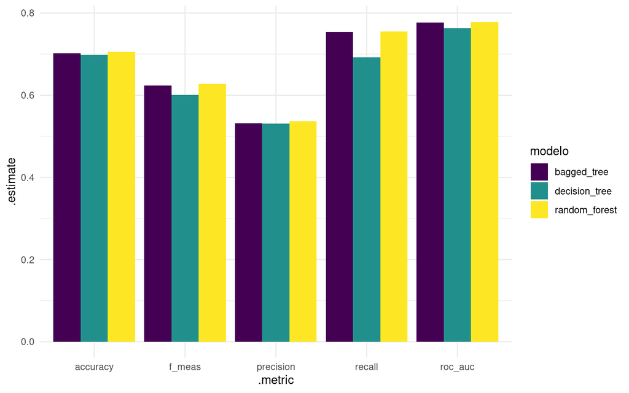

```r
rbind(metrics_dt, metrics_bagging, metrics_random) %>%
  ggplot(aes(x = .metric, y = .estimate, fill = modelo))+
  geom_col(position = "dodge")+
  scale_fill_viridis_d()+
  theme_minimal()
```